# Report3

## Load the R packages

```r
library(knitr)
library(readr)
library(tidyverse)
library(dplyr)
library(tidyr)
library(stringr)
library(purrr)
library(httr)
library(DBI)
library(tibble)
library(leaflet)
library(ggmap)
```

## Preparations: connect to the database and get the individual tables

```r
politicians <- dbConnect(RSQLite::SQLite(), "zh_politicians.db")

addresses    <- DBI::dbGetQuery(politicians, "SELECT * FROM ADDRESSES;")
affiliations <- DBI::dbGetQuery(politicians, "SELECT * FROM AFFILIATIONS;")
mandates     <- DBI::dbGetQuery(politicians, "SELECT * FROM MANDATES;")
persons      <- DBI::dbGetQuery(politicians, "SELECT * FROM persons;")
```

## Part 1

Do some data cleaning: when the current politician is still active (i.e. MANDATE_END_YEAR is equal to 0), we set the year to 0. Remove politicians where either the MANDATE_START_YEAR oder MANDATE_END_YEAR is equal to zero.

```r
mandates_cleaned <- mandates %>%
  filter((MANDATE_START_YEAR > 0) & (MANDATE_END_YEAR > 0))
```

Pull the start and end year to compute all the years the politicians were active:

```r
start_dates <- mandates_cleaned %>% pull(MANDATE_START_YEAR)
end_dates   <- mandates_cleaned %>% pull(MANDATE_END_YEAR)
range_dates <- map2(start_dates, end_dates, seq)
```

We use the *list-colum* function to get all the mandates per year:

```r
mandates_short_and_cleaned <- mandates_cleaned %>%
  mutate(FULL_YEARS = range_dates) %>%
  unnest(FULL_YEARS) %>%
  select(FULL_YEARS, ASSEMBLY)
```

Then we need to summarize all the mandates per year and assembly type:

```r
mandates_short_and_cleaned_summarized <- mandates_short_and_cleaned %>%
  group_by(FULL_YEARS, ASSEMBLY) %>%
  summarize(TOTAL_MANDATES = n())
```

Now we do the plot:

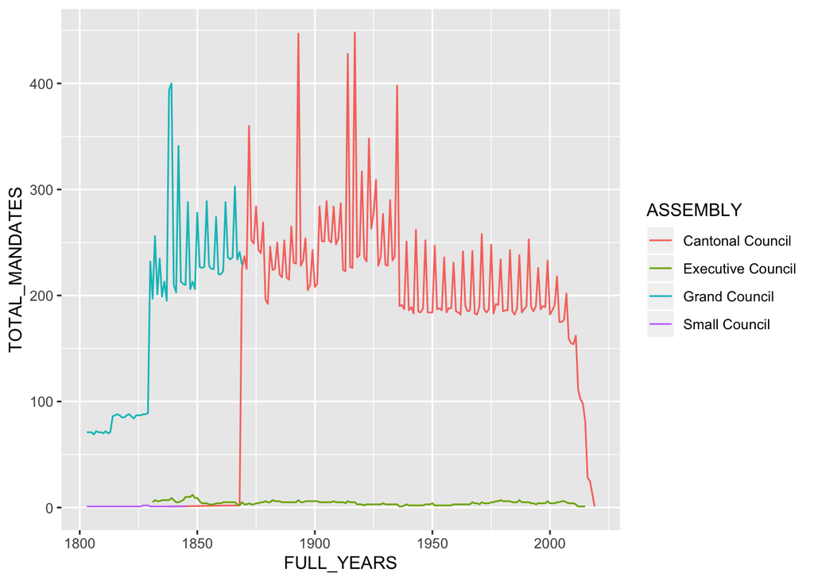

```r
ggplot(mandates_short_and_cleaned_summarized, aes(x=FULL_YEARS, y=TOTAL_MANDATES, color=ASSEMBLY)) +
  geom_line()
```

## Part 2

Do the initial data cleaning for the PERSONS table of the database and rename the ID column for the merge in the next step:

```r
persons_cleaned <- persons %>%
  filter((GENDER == 'w') | (GENDER == 'm')) %>%
  rename(PERSON_ID = ID)
```

Now merge the relevant data of the two tables:

```r
mandates_persons_cleaned <- mandates_cleaned %>%
  full_join(persons_cleaned)
```

Re-do the steps from Part 1 for this merged table (there are certainly more elegant ways to copy the result from Part 1 instead of re-doing the calculations - but I decided on this approach to make sure the results are correct due to the individual data cleaning of the tables):

```r
# Cleaning negative mandates
mandates_persons_cleaned <- mandates_persons_cleaned %>%
  mutate(DIFFERENCE = (MANDATE_END_YEAR-MANDATE_START_YEAR)) %>%
  filter(DIFFERENCE>=0)

# Unnesting and selecting the relevant columns
rm(start_dates, end_dates, range_dates)
start_dates <- mandates_persons_cleaned %>% pull(MANDATE_START_YEAR)
end_dates   <- mandates_persons_cleaned %>% pull(MANDATE_END_YEAR)
range_dates <- map2(start_dates, end_dates, seq)
mandates_persons_short_and_cleaned <- mandates_persons_cleaned %>%
  mutate(FULL_YEARS = range_dates) %>%
  unnest(FULL_YEARS) %>%
  select(FULL_YEARS, ASSEMBLY, GENDER)
```

Then we need to summarize all the mandates per year and assembly type:

```r
mandates_persons_short_and_cleaned_summarized <- mandates_persons_short_and_cleaned %>%
  group_by(FULL_YEARS, ASSEMBLY, GENDER) %>%
  summarize(TOTAL_MANDATES = n())
```

Now we do the plot:

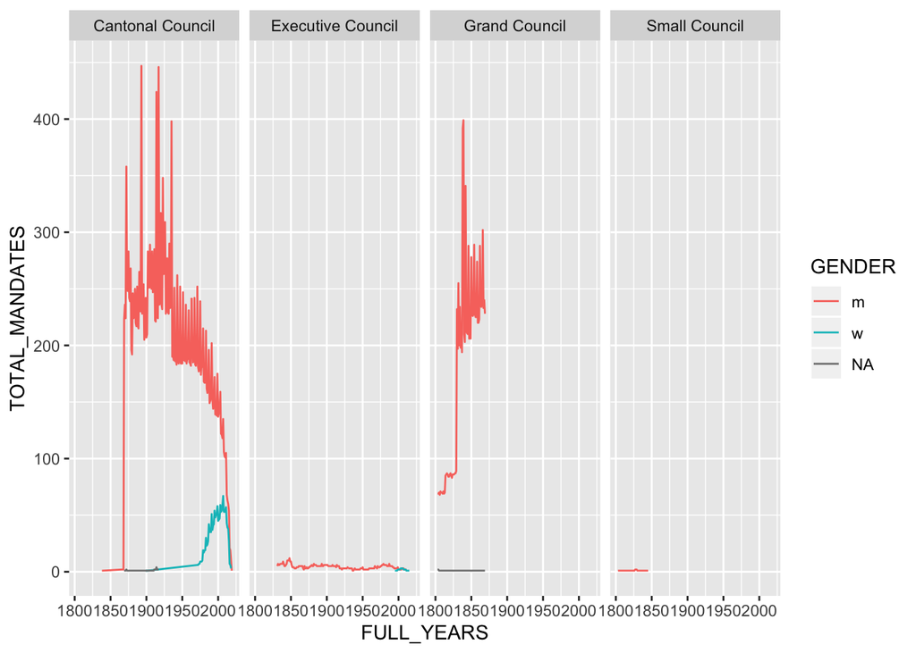

```r
ggplot(mandates_persons_short_and_cleaned_summarized,aes(x=FULL_YEARS, y=TOTAL_MANDATES, color=GENDER)) +
  geom_line() +
  facet_grid(cols=vars(ASSEMBLY))
```

## Part 3

Start with the usual data cleaning and data unnesting:

```r
affiliations_cleaned <- affiliations %>%
  mutate(PERIOD = (AFFILIATION_END_YEAR - AFFILIATION_START_YEAR)) %>%
  filter(PERIOD > 0)

rm(start_dates, end_dates, range_dates)
start_dates <- affiliations_cleaned %>% pull(AFFILIATION_START_YEAR)
end_dates   <- affiliations_cleaned %>% pull(AFFILIATION_END_YEAR)
range_dates <- map2(start_dates, end_dates, seq)

affiliations_2000 <- affiliations_cleaned %>%
  mutate(FULL_YEARS = range_dates) %>%
  unnest(FULL_YEARS) %>%
  filter(FULL_YEARS==2000) %>%
  select(ID, PARTY) %>%
  group_by(PARTY) %>%
  summarize(SEATS = n()) %>%
  mutate(PROP = 100*SEATS / sum(SEATS))
```

Now we do the plot:

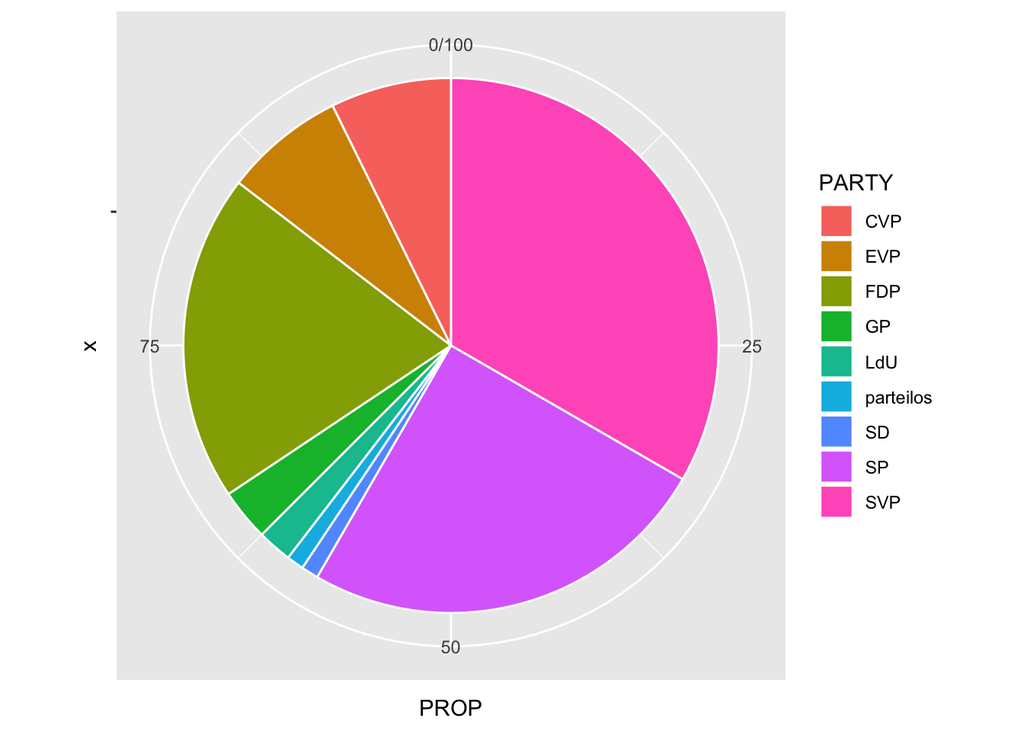

```r
ggplot(affiliations_2000, aes(x = "", y = PROP, fill = PARTY)) +
  geom_bar(width = 1, stat = "identity", color = "white") +
  coord_polar("y", start = 0)
```

## Part 4

Start again with data manipulation tasks:

```r
affiliations_cleaned_and_summarized <- affiliations_cleaned %>%
  mutate(FULL_YEARS = range_dates) %>%
  unnest(FULL_YEARS) %>%
  group_by(FULL_YEARS, PARTY) %>%
  summarize(TOTAL_MANDATES = n())
```

Now we do the plot but select only a couple of parties and limit the time period since 1950:

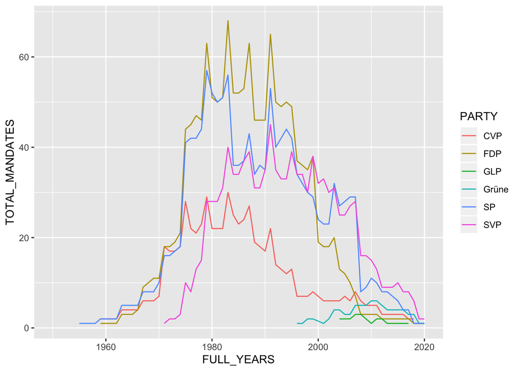

```r
  affiliations_cleaned_and_summarized %>%
  filter((PARTY=="SVP") | (PARTY=="SP")  | (PARTY=="Grüne")  | (PARTY=="FDP")  | (PARTY=="CVP")  | (PARTY=="GLP")) %>%
  ggplot(aes(x=FULL_YEARS, y=TOTAL_MANDATES, color=PARTY)) +  geom_line() + xlim(1950, 2020)
```

## Part 5

Start again with data manipulation tasks of the PERSONS table:

```r
persons[persons==""]<-NA
persons %>% as_tibble() %>%
  filter(as.numeric(YEAR_OF_DEATH)>0 & as.numeric(YEAR_OF_BIRTH>0) & !is.na(TITLE)) %>%
  mutate(LIFE_SPAN = (as.numeric(YEAR_OF_DEATH) - as.numeric(YEAR_OF_BIRTH))) %>%
  summarise(AVERAGE_LIFE_SPAN = mean(LIFE_SPAN))
```

| AVERAGE_LIFE_SPAN |
| --- |
| 74.32143 |

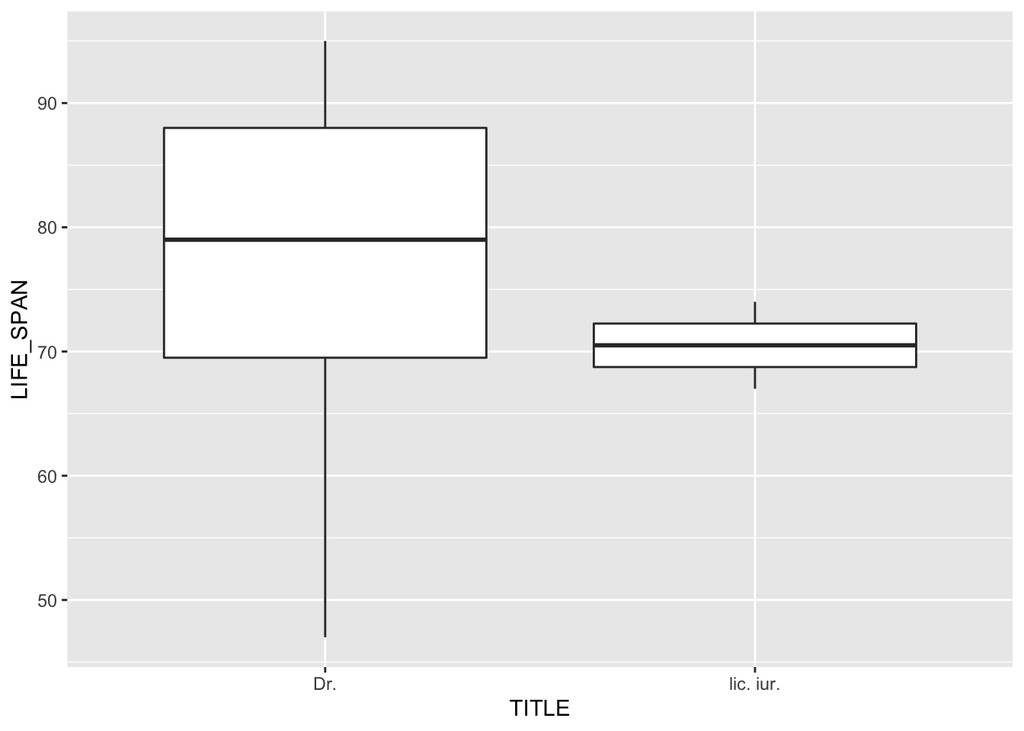

```r
persons %>% as_tibble() %>%
  filter(as.numeric(YEAR_OF_DEATH)>0 & as.numeric(YEAR_OF_BIRTH)>0) %>%
  mutate(LIFE_SPAN = (as.numeric(YEAR_OF_DEATH) - as.numeric(YEAR_OF_BIRTH))) %>%
  filter((TITLE=="Dr.") | (TITLE=="lic. iur.")) %>%
  ggplot(aes(TITLE, LIFE_SPAN)) + geom_boxplot()
```

## Part 6

The following computations are based on the previously merged MANDATES and PERSONS tables after some data cleaning (i.e. that there is known start and end date of the mandate):

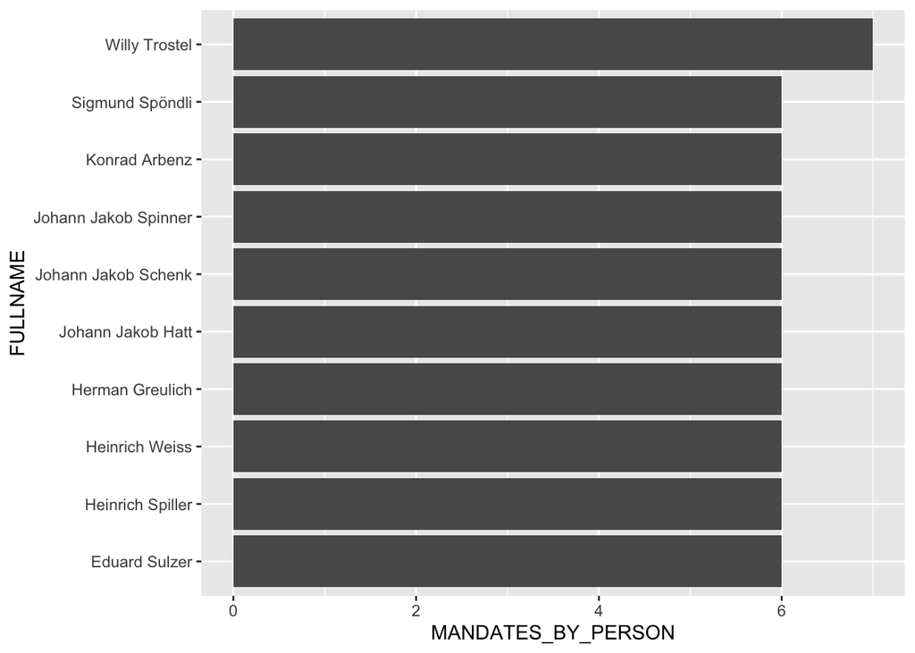

```r
mandates_persons_cleaned %>%
  as_tibble() %>%
  unite(FULLNAME, FIRSTNAME, LASTNAME, sep = ' ') %>%
  group_by(PERSON_ID) %>%
  mutate(MANDATES_BY_PERSON = n()) %>%
  arrange(desc(MANDATES_BY_PERSON)) %>%
  select(FULLNAME, MANDATES_BY_PERSON) %>%
  unique() %>%
  head(10) %>%
  ggplot(aes(y=MANDATES_BY_PERSON, x=FULLNAME)) +
  geom_bar(stat ="identity") + coord_flip()
```

## Part 7

Re-do some previous calculations for the MANDATES data:

```r
rm(start_dates,end_dates,range_dates)
start_dates <- mandates_cleaned %>% pull(MANDATE_START_YEAR)
end_dates   <- mandates_cleaned %>% pull(MANDATE_END_YEAR)
range_dates <- map2(start_dates, end_dates, seq)
```

The basic idea is here to calcalature for each politician and for each year the standard deviation of his oder her mandates: if the standard deviation of the mandate IDs is non-zero, then the politician has several mandate IDs for a given year:

```r
mandates_cleaned %>%
  mutate(FULL_YEARS = range_dates) %>%
  unnest(FULL_YEARS) %>%
  group_by(PERSON_ID, FULL_YEARS) %>%
  summarize(N_MANDATES = sd(ID)) %>%
  pull(N_MANDATES) %>%
  unique() %>%
  length()
```

```
## [1] 11
```

Thus we have several politicians with multiple mandates at the same time.

## Part 8

```r
affiliations %>% as_tibble() %>%
  group_by(PERSON_ID) %>%
  summarize(PARTY_MEMBERSHIP = n()) %>%
  filter(PARTY_MEMBERSHIP > 1) %>%
  summarize(n())
```

| n() |
| --- |
| 1351 |

## Part 9

Select 20 Addresses sort of randomly…

```r
addresses[addresses==""]<-NA

selection <- addresses %>%
  filter(!is.na(STREET) & !is.na(HOUSE_NUMBER) & !is.na(POSTAL_CODE) & !is.na(CITY)) %>%
  unite(LOCATION, STREET, CITY , sep = ' ') %>%
  head(20)
```

As I’d like not to register with Google to get the API key, I looked up some addressess manually with Google’s Geocoding service based on the tibble above:

```r
#Im Baumgarten Greifensee: 47,371, 8.676
#Lägernstrasse Schleinikon: 47.485, 8.415
#Frohbühlstrasse Opfikon: 47.429, 8.555
```

Now we can do the plot - due to privacy reasons, only the Person-ID of the politician is provided in the popup:

```r
m <- leaflet() %>%
  addTiles() %>%
  addMarkers(lat=47,371, lng=8.676, popup="Person-ID 1659 of zh_politicians.db.zip") %>%
  addMarkers(lat=47.485, lng=8.415, popup="Person-ID 1834 of zh_politicians.db.zip") %>%
  addMarkers(lat=47.429, lng=8.555, popup="Person-ID 1893 of zh_politicians.db.zip")
m  # Print the map
```

[interactive chart not shown]